# CueStrength within subject

Manuel Bohn

17 3 2018

```r
###
library(tidyverse)
library(knitr)
library(langcog)
library(ggthemes)
## importing data
d <- read_csv(file="cue.data.csv") %>%
  mutate(trial_type = ifelse(trial == "train", "train", "test"))
```

Sanity checks.

```r
## performance in training and test
d %>%
  group_by(trial_type) %>%
  summarise(n = length(unique(id)),
            correct = mean(correct)) %>%
  knitr::kable(digits = 3)
```

| trial_type | n | correct |
| --- | --- | --- |
| test | 60 | 0.798 |
| train | 60 | 0.933 |

Plot with all data for all conditions. Interestingly, the type of communicative act does not seem to matter. I wonder if the same would be true for children.

This is all within subject, so there might be carry over effects. Next I’m only looking at trial 1.

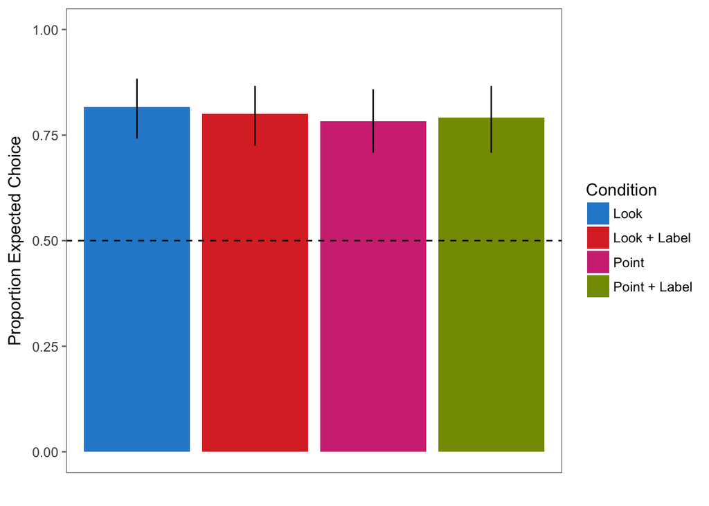

```r
ms <- d %>%
  filter(trial_type == "test") %>%
  group_by(condition, id) %>%
  summarise(correct = mean(correct)) %>%
  multi_boot_standard(col = "correct")

ggplot(ms,
       aes(x = condition, y = mean, fill = condition)) +
  geom_bar(stat="identity") +
  geom_linerange(aes(ymin = ci_lower, ymax = ci_upper)) +
  geom_hline(yintercept = 0.5, lty=2)+
  labs(x="",y="Proportion Expected Choice")+
  theme_few(base_size = 12) +
  ylim(0,1)+
  theme(axis.text.x=element_blank(),axis.ticks.x=element_blank())+
  scale_fill_solarized(name="Condition",
                     breaks=c("look", "lookLabel","point","pointLabel"),
                     labels=c("Look", "Look + Label","Point","Point + Label"))
```

First, check how much data for trial 1 we have per condition (order was completely randomized). Roughly equally distributed.

```r
d %>%
  filter(trial == "1") %>%
  group_by(condition) %>%
  summarise(n = length(unique(id)),
            correct = mean(correct)) %>%
  knitr::kable(digits = 2)
```

| condition | n | correct |
| --- | --- | --- |
| look | 14 | 0.71 |
| lookLabel | 13 | 0.92 |
| point | 19 | 0.79 |
| pointLabel | 14 | 0.86 |

Plot for trial 1. Similar to overall pattern, maybe a little weaker for look alone. Not sure if following up between subject would be worth it?

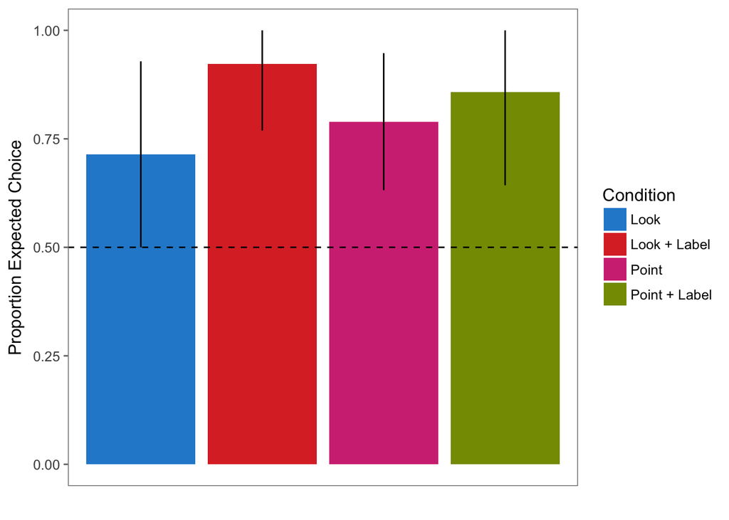

```r
ms <- d %>%
  filter(trial == "1") %>%
  group_by(condition, id) %>%
  summarise(correct = mean(correct)) %>%
  multi_boot_standard(col = "correct")

ggplot(ms,
       aes(x = condition, y = mean, fill = condition)) +
  geom_bar(stat="identity") +
  geom_linerange(aes(ymin = ci_lower, ymax = ci_upper)) +
  geom_hline(yintercept = 0.5, lty=2)+
  labs(x="",y="Proportion Expected Choice")+
  theme_few(base_size = 12) +
  ylim(0,1)+
  theme(axis.text.x=element_blank(),axis.ticks.x=element_blank())+
  scale_fill_solarized(name="Condition",
                     breaks=c("look", "lookLabel","point","pointLabel"),
                     labels=c("Look", "Look + Label","Point","Point + Label"))
```

Effect of target object location on table. Inner = closer to the agent, outer = further away. General bias to pick the inner object, considerably stronger for point. Probably because the poitning finger is closer to the inner object.

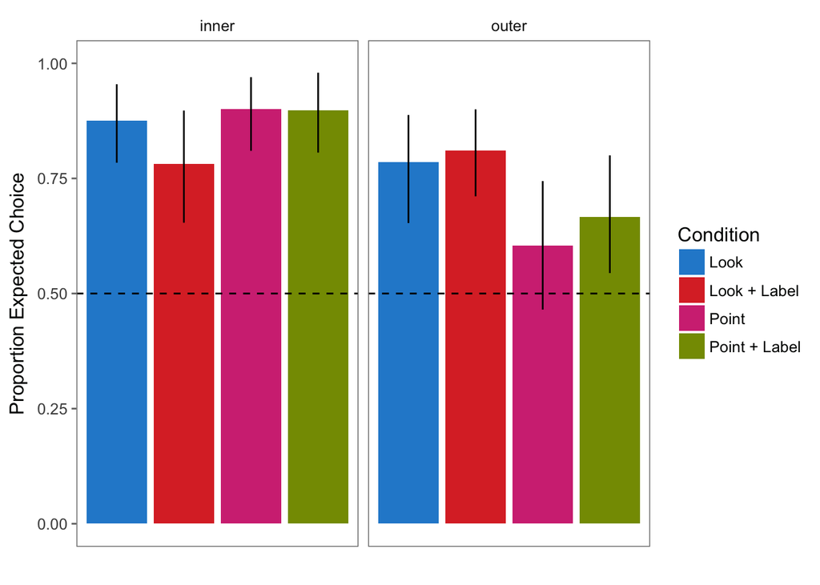

```r
## performance in training and test
ms <- d %>%
  filter(trial_type == "test") %>%
  group_by(targetOnTable,condition, id) %>%
  summarise(correct = mean(correct)) %>%
  multi_boot_standard(col = "correct")

ggplot(ms,
       aes(x = condition, y = mean, fill = condition,frame = targetOnTable)) +
  geom_bar(stat="identity") +
  geom_linerange(aes(ymin = ci_lower, ymax = ci_upper)) +
  geom_hline(yintercept = 0.5, lty=2)+
  facet_wrap(~ targetOnTable) +
  labs(x="",y="Proportion Expected Choice")+
  theme_few(base_size = 12) +
  ylim(0,1)+
  theme(axis.text.x=element_blank(),axis.ticks.x=element_blank())+
  scale_fill_solarized(name="Condition",
                     breaks=c("look", "lookLabel","point","pointLabel"),
                     labels=c("Look", "Look + Label","Point","Point + Label"))
```

Condition by trial overall. Looks pretty random.

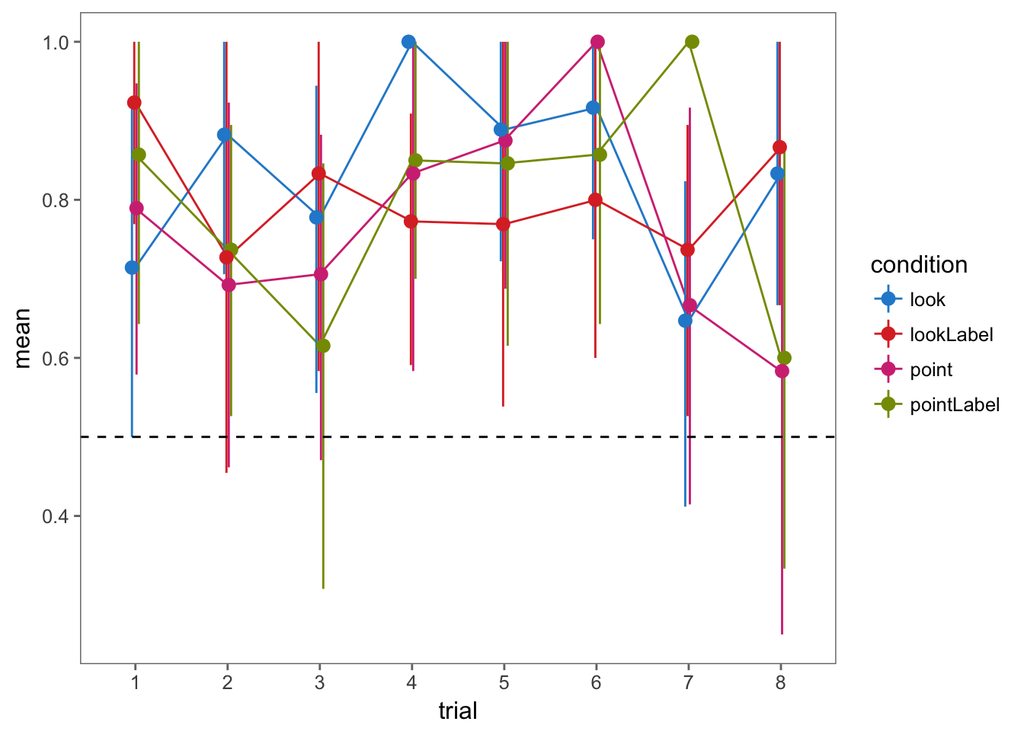

```r
ms <- d %>%
  filter(trial_type == "test") %>%
  group_by(condition, trial, id) %>%
  summarise(correct = mean(correct)) %>%
  multi_boot_standard(col = "correct")

ggplot(ms,
       aes(x = trial, y = mean, col = condition)) +
  geom_line(aes(group= condition)) +
  geom_pointrange(aes(ymin = ci_lower, ymax = ci_upper),
                  position = position_dodge(width = .1)) +
  geom_hline(yintercept = 0.5, lty=2)+
  theme_few() +
  scale_colour_solarized()
```

Conditions by agents.

```r
# d %>%
#   filter(trial_type == "test") %>%
#   group_by(agent,condition) %>%
#   summarise(n = length(agent),
#             correct = mean(correct)) %>%
#   knitr::kable(digits = 2)
```

Agent effect. Cat seems a little strange in point label, but also very few data.

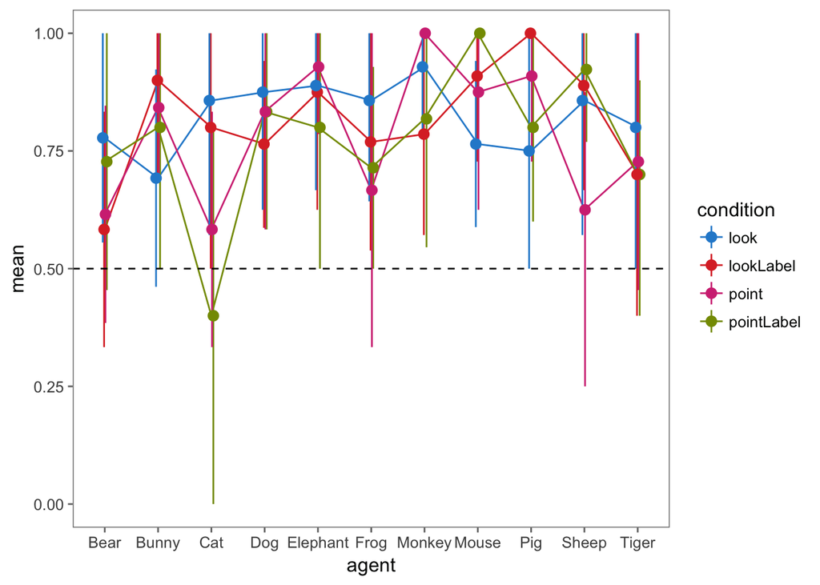

```r
ms <- d %>%
  filter(trial_type == "test") %>%
  group_by(condition, agent, id) %>%
  summarise(correct = mean(correct)) %>%
  multi_boot_standard(col = "correct")

ggplot(ms,
       aes(x = agent, y = mean, col = condition)) +
  geom_line(aes(group= condition)) +
  geom_pointrange(aes(ymin = ci_lower, ymax = ci_upper),
                  position = position_dodge(width = .1)) +
  geom_hline(yintercept = 0.5, lty=2)+
  theme_few() +
  scale_colour_solarized()
```

Tests against chance per condition. We only have 2 trials per subject per condition, that’s why t-tests aren’t the best option. I used wilcoxon tests instead. We would get the same info out of the model but this might be helpful for a quick overview. There is no Bayesian version of a wilcoxon test, yet.

```r
## Wilcoxon tests against chance
library(exactRankTests)
d %>%
  filter(trial_type == "test") %>%
  group_by(condition, id) %>%
  summarise(correct = mean(correct)) %>%
  summarise(correct = list(correct)) %>%
  group_by(condition) %>%
  mutate(mean= mean(unlist(correct)),
         stat = wilcox.exact(unlist(correct), mu = 0.5)$statistic,
         p = wilcox.exact(unlist(correct), mu = 0.5)$p.value) %>%
  select(condition,mean,stat,p) %>%
  knitr::kable(digits = 3)
```

| condition | mean | stat | p |
| --- | --- | --- | --- |
| look | 0.817 | 922.5 | 0 |
| lookLabel | 0.800 | 779.0 | 0 |
| point | 0.783 | 758.5 | 0 |
| pointLabel | 0.792 | 920.0 | 0 |

Brm Model. It’s the first time I run a Bayesian model, so I’m not sure how to properly tweak the settings. Whatever I do, I get the following error message:

“The model has not converged (some Rhats are > 1.1). Do not analyse the results! We recommend running more iterations and/or setting stronger priors”

I did run more iterations and also adjusted the delta level. There are some changes in the fixed effects depending on the settings.

Model output with 10 times the iterations and higher delta is pasted below.

In any case, the output reflects what we see in the graph: No difference between conditions (here look is the reference level).

```r
## model
library(brms)
data_inf <- d%>%
  filter(trial_type == "test")%>%
  mutate(trial = scale(as.numeric(trial), center = TRUE, scale=FALSE))

# registered  model
bm <- brm(correct ~ condition +
              (condition |id) + (condition |agent),
          data = data_inf, family = bernoulli(),
          control = list(adapt_delta = 0.80),
          iter = 2000)
```

[output not shown]

[output cut: 40 more lines]

[output not shown]

```r
summary(bm)
```

```
##  Family: bernoulli
##   Links: mu = logit
## Formula: correct ~ condition + (condition | id) + (condition | agent)
##    Data: data_inf (Number of observations: 480)
## Samples: 4 chains, each with iter = 2000; warmup = 1000; thin = 1;
##          total post-warmup samples = 4000
##     ICs: LOO = NA; WAIC = NA; R2 = NA
##
## Group-Level Effects:
## ~agent (Number of levels: 11)
##                                             Estimate Est.Error l-95% CI
## sd(Intercept)                                   0.32      0.24     0.01
## sd(conditionlookLabel)                          0.48      0.40     0.02
## sd(conditionpoint)                              1.13      0.93     0.06
## sd(conditionpointLabel)                         0.53      0.44     0.02
## cor(Intercept,conditionlookLabel)              -0.04      0.45    -0.85
## cor(Intercept,conditionpoint)                   0.11      0.44    -0.76
## cor(conditionlookLabel,conditionpoint)          0.12      0.44    -0.76
## cor(Intercept,conditionpointLabel)             -0.03      0.44    -0.82
## cor(conditionlookLabel,conditionpointLabel)     0.07      0.44    -0.78
## cor(conditionpoint,conditionpointLabel)         0.12      0.45    -0.74
##                                             u-95% CI Eff.Sample Rhat
## sd(Intercept)                                   0.92       1527 1.00
## sd(conditionlookLabel)                          1.48       1745 1.00
## sd(conditionpoint)                              3.56        425 1.01
## sd(conditionpointLabel)                         1.65       2149 1.00
## cor(Intercept,conditionlookLabel)               0.80       2703 1.00
## cor(Intercept,conditionpoint)                   0.85       1286 1.00
## cor(conditionlookLabel,conditionpoint)          0.85       1600 1.00
## cor(Intercept,conditionpointLabel)              0.79       2821 1.00
## cor(conditionlookLabel,conditionpointLabel)     0.82       2800 1.00
## cor(conditionpoint,conditionpointLabel)         0.85       2973 1.00
##
## ~id (Number of levels: 60)
##                                             Estimate Est.Error l-95% CI
## sd(Intercept)                                   1.14      0.35     0.50
## sd(conditionlookLabel)                          0.68      0.52     0.02
## sd(conditionpoint)                              1.10      0.98     0.04
## sd(conditionpointLabel)                         1.35      0.87     0.07
## cor(Intercept,conditionlookLabel)              -0.11      0.42    -0.83
```

[output cut: 12 more lines]

```
## cor(conditionlookLabel,conditionpoint)          0.87        956 1.00
## cor(Intercept,conditionpointLabel)              0.74       1782 1.00
## cor(conditionlookLabel,conditionpointLabel)     0.79        885 1.00
## cor(conditionpoint,conditionpointLabel)         0.79       1252 1.00
##
## Population-Level Effects:
##                     Estimate Est.Error l-95% CI u-95% CI Eff.Sample Rhat
## Intercept               1.86      0.37     1.22     2.63       2064 1.00
## conditionlookLabel      0.01      0.48    -0.89     1.00       2060 1.00
## conditionpoint          0.27      0.87    -0.92     2.62        414 1.01
## conditionpointLabel     0.21      0.64    -0.86     1.70       1104 1.00
##
## Samples were drawn using sampling(NUTS). For each parameter, Eff.Sample
## is a crude measure of effective sample size, and Rhat is the potential
## scale reduction factor on split chains (at convergence, Rhat = 1).
```

```r
# 20 000 iterations and adapt_delta = 0.99
#
# Population-Level Effects:
#                     Estimate Est.Error l-95% CI u-95% CI Eff.Sample Rhat
# Intercept               1.85      0.36     1.20     2.62      40000 1.00
# conditionlookLabel      0.03      0.49    -0.87     1.09      40000 1.00
# conditionpoint          0.44      1.27    -0.94     3.62       3751 1.00
# conditionpointLabel     0.23      0.67    -0.86     1.80      16832 1.00
```